# What is the Effect of Foreign Investment on CO2 Emmissions

Justin Hurcombe, Riley Kates, and Mike Quach

12/3/2023

# Abstract

The study investigates the connection between CO2 emissions and various socio-economic factors, such as foreign direct investment (FDI), GDP per Capita, and sectoral contributions to GDP. The researchers propose a log-linear model that includes squared and cubic terms for FDI and squared terms for log (GDP Per Capita) and examine potential non-linear associations. Although the R-squared values suggest a good model fit, there are concerns regarding the statistical significance of FDI in some models. We conducted hypothesis tests, examined multicollinearity, and considered alternative models, demonstrating an understanding of the complexities involved. The findings are with caution, highlighting their theoretical and practical relevance. However, further refining and considering potential limitations, such as omitted variable bias, would strengthen the regression analysis’s robustness and validity.

# Introduction

### Question

The objective in this study is to examine what kind of effect foreign direct investment (FDI) has on CO2 emissions in a country. With the strong popularity of globalization today, more countries are investing abroad every year. At the same time, our global climate is increase in an alarming rate. With the high levels of CO2 in the atmosphere, global warming continues to be an issue for generations to come. That’s why we are examining a possible connection between foreign investment and CO2 emissions in order to conclude if increasing production and business in foreign countries is also contributing to the climate issue.

### Hypothesis

We believe that FDI will have a negative effect, where an increase in foreign investment to another country will decrease CO2 emissions in that country. This is because one of the reasons behind foreign investment is offshoring of production from the countries providing financial capital. As a country offshores its production abroad, there is less overall CO2 emissions as a result of production in its own borders. Conversely, as countries receive foreign investment from other countries, its production capabilities can increase as it uses the money to improve businesses and build factories. The increase in production in these companies should increase their CO2 emissions, meaning a decrease in FDI should increase CO2 emissions.

### Data

This data set covers 171 observations and 21 variables about different metrics of almost every country in the world in 2020.

**Per_Agri**: % of GDP that is agriculture based

**Bus_Support:** Ease of Doing Business Index. The higher the moment relaxed the regulations for businesses

**Per_Export**: % of GDP from Export

**GDP**: Measure of Gross Domestic Produce of the country

**Per_Industry**: % of GDP that is industry based

**Export**: Total value of export within the year

**Import**: Total of import within the year

**Net.Trade**: Export minus Import (US$ Billions)

**GDP.Per.Capita**: GDP per person (USD thousands)

**Population.Density**: How many people per km2 (thousands per sq. km)

**CO2** : CO2 emissions (Metric Tons per Capita)

**FDI** : Foreign Direct Investment, Net Inflows (US$ Billions)

**Exporter**: Dummy variable that is 1 if net trade is positive; otherwise it is 0

```
Summary Statistics
================================================
Statistic              N   Mean  Median St. Dev.
------------------------------------------------
Per_Agri              171 10.68   7.70    9.96
Bus_Support           171 61.54  61.98   14.59
Per_Edu               171 13.61  12.99    5.42
Per_Export            171 38.03  30.66   29.37
GDP                   171 487.43 43.58  2,038.62
Per_Health            171  6.83   6.41    2.90
Per_Import            171 43.48  37.88   25.69
Per_Industry          171 25.63  23.78    9.94
R.D                   171 11.37   0.09   63.75
Per_Service           171 55.30  55.02   12.71
Population            171  0.04   0.01    0.16
Export                171 123.33 14.43   327.78
Import                171 119.98 15.54   328.71
Education.Expenditure 171 57.55   5.41   241.87
Health.Expenditure    171 52.78   2.52   315.24
Net.Trade             171  3.35  -0.34   61.22
GDP.Per.Capita        171 13.61   5.34   19.37
Population.Density    171  0.19   0.08    0.64
CO2                   171  3.91   2.41    4.77
FDI                   171  5.93   0.55   40.16
Exporter              171  0.39    0      0.49
------------------------------------------------
```

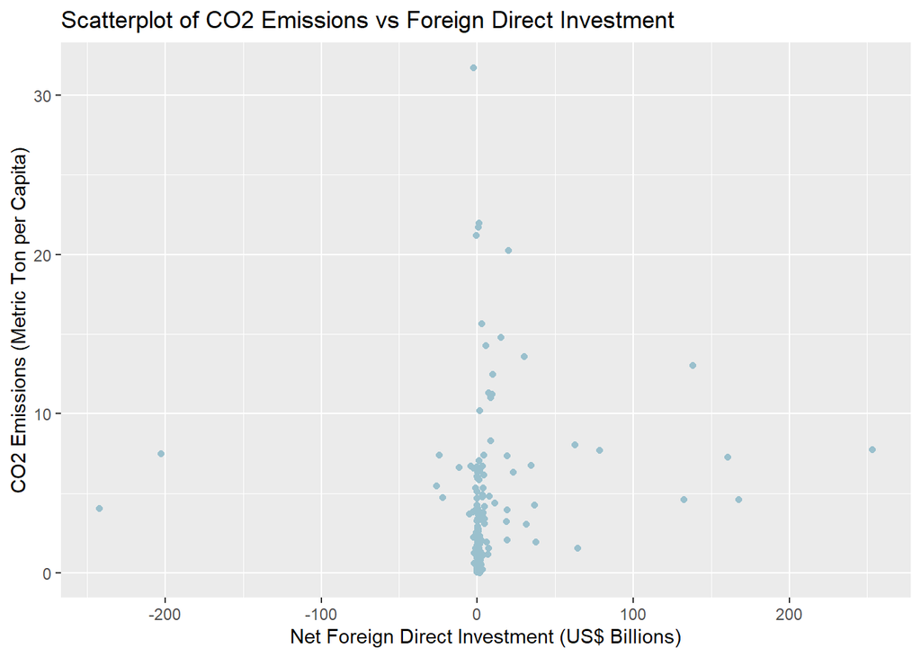

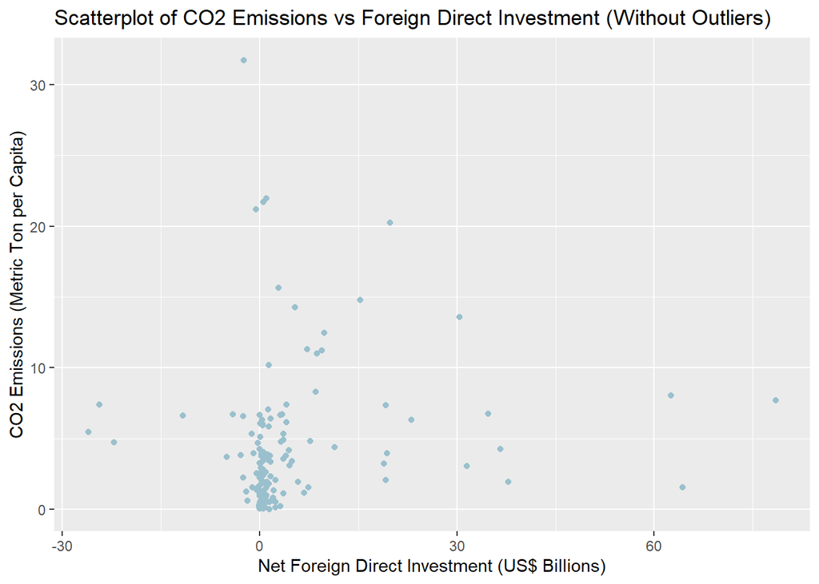

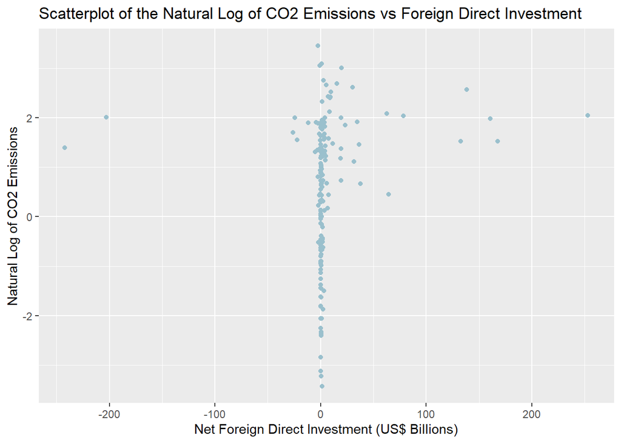

The original scatterplot (see scatterplot 1) of the data shows a tight group between zero and five metric tons per capita of CO2 emissions, with no apparent relationship between the two variables. However, when we temporarily remove the outliers in foreign direct investment (see scatterplot 2), the data appears to resemble a log function, where it clusters around the chart’s origin and increases in a slight curve. With this observation, we took the log of CO2 emissions to see its effect on the scatterplot (see scatterplot 3), and what results is a more linear scatterplot that we can use for OLS regression in our analysis.

# Analysis

### Base Model Regression

```
Factors affecting CO2 Emissions
===========================================================================
                                      Dependent variable:
                    -------------------------------------------------------
                                           log(CO2)
                      (1)     (2)     (3)     (4)     (5)     (6)     (7)
---------------------------------------------------------------------------
FDI                  0.004   0.002   0.002   0.002   0.002   0.003   0.001
                    (0.003) (0.001) (0.001) (0.001) (0.001) (0.001) (0.001)

log(GDP.Per.Capita)          0.870   0.877   0.728   0.758   0.787   0.753
                            (0.045) (0.046) (0.087) (0.076) (0.080) (0.075)

Population.Density                  -0.101  -0.094  -0.061  -0.058
                                    (0.046) (0.045) (0.044) (0.046)

Per_Agri                                    -0.027  -0.020  -0.018  -0.020
                                            (0.011) (0.010) (0.010) (0.010)

Per_Industry                                         0.025   0.025   0.025
                                                    (0.007) (0.007) (0.007)

Export                                                      -0.0005
                                                            (0.001)

Import                                                      0.0002
                                                            (0.001)

Constant             0.583  -0.896  -0.890  -0.344  -1.120  -1.164  -1.131
                    (0.113) (0.098) (0.098) (0.274) (0.319) (0.316) (0.317)

---------------------------------------------------------------------------
Observations          171     171     171     171     171     171     171
R2                   0.014   0.743   0.745   0.759   0.788   0.790   0.787
Adjusted R2          0.009   0.739   0.740   0.753   0.781   0.781   0.782
Residual Std. Error  1.421   0.728   0.728   0.709   0.667   0.668   0.667
F Statistic          2.468  242.255 162.215 130.711 122.349 87.569  153.212
===========================================================================
Note:                                                                    NA
```

H0: β1| β2 | β3 | β4 | β5 | β6 = 0 H0: β1| β2 | β3 | β4 | β5 | β6 ≠ 0

Model 1: FDI: T-score = 1.33 not significant at 5%

```
Linear hypothesis test

Hypothesis:
Per_Industry = 0
Per_Agri = 0

Model 1: restricted model
Model 2: log(CO2) ~ FDI + log(GDP.Per.Capita) + Population.Density + Per_Agri +
    Per_Industry + Export + Import

Note: Coefficient covariance matrix supplied.

  Res.Df Df      F    Pr(>F)
1    165
2    163  2 11.739 1.726e-05 ***
---
Signif. codes:  0 '***' 0.001 '**' 0.01 '*' 0.05 '.' 0.1 ' ' 1
```

```
Linear hypothesis test

Hypothesis:
Export = 0
Import = 0

Model 1: restricted model
Model 2: log(CO2) ~ FDI + log(GDP.Per.Capita) + Population.Density + Per_Agri +
    Per_Industry + Export + Import

Note: Coefficient covariance matrix supplied.

  Res.Df Df      F Pr(>F)
1    165
2    163  2 1.3127 0.2719
```

H0: Per_Industry =0 and Per_Agri =0 H1: Per_Industry ≠ 0 and/or Per_Agri ≠ 0 At 5%, the F-statistic is 11.739 > 3. We can reject the null hypothesis and conclude that one or both variables are different from 0.

H0: Export =0 and Import =0 H1: Export ≠ 0 and/or Import ≠ 0 At 5%, P value of restricted model is 1.3127 < 3. We cannot reject the null hypothesis, and we conclude that both variables are not statistically different from 0.

As such the base model will be lr7: log(CO2)~FDI + log(GDP.Per.Capita) + Per_Agri + Per_Industry

### Alternative Regression Specifications

```
Alternative Regression Models
=========================================================================================================
                                                            Dependent variable:
                                   ----------------------------------------------------------------------
                                                                  log(CO2)
                                      (1)       (2)      (3)     (4)     (5)     (6)      (7)      (8)
---------------------------------------------------------------------------------------------------------
FDI                                  0.002    -0.003    0.002   0.002   0.002   0.001    0.007    0.001
                                    (0.001)   (0.002)  (0.001) (0.001) (0.001) (0.001)  (0.018)  (0.001)

I(log(GDP.Per.Capita))               0.770     0.792    0.745   0.763   0.756   1.316    1.731    1.738
                                    (0.076)   (0.077)  (0.072) (0.077) (0.074) (0.136)  (0.266)  (0.249)

I(log(GDP.Per.Capita)2)                                                        -0.142
                                                                               (0.027)

Per_Industry                         0.025     0.025    0.025   0.025   0.024   0.022    0.021    0.021
                                    (0.007)   (0.007)  (0.007) (0.008) (0.007) (0.006)  (0.005)  (0.005)

Per_Agri                            -0.019    -0.018   -0.024  -0.019  -0.024  -0.008   -0.017    -0.017
                                    (0.010)   (0.010)  (0.009) (0.010) (0.010) (0.009)  (0.008)  (0.008)

I(FDI2)                            -0.00001  -0.00001
                                   (0.00001) (0.00000)

I(FDI3)                                       0.00000
                                             (0.00000)

Per_Edu                                                 0.016           0.016
                                                       (0.012)         (0.012)

Per_Health                                                     -0.008  -0.009
                                                               (0.023) (0.023)

Bus_Support                                                                              0.031    0.031
                                                                                        (0.009)  (0.009)

R.D                                                                                      0.004    0.001
                                                                                        (0.008)  (0.0004)

```

[output cut: 11 more lines]

```

I(log(GDP.Per.Capita)):Bus_Support                                                      -0.016    -0.016
                                                                                        (0.004)  (0.004)

Constant                            -1.155    -1.160   -1.292  -1.074  -1.233  -1.423   -2.718    -2.715
                                    (0.314)   (0.309)  (0.358) (0.403) (0.430) (0.252)  (0.565)  (0.553)

---------------------------------------------------------------------------------------------------------
Observations                          171       171      171     171     171     171      171      171
R2                                   0.789     0.793    0.790   0.787   0.790   0.830    0.839    0.838
Adjusted R2                          0.783     0.786    0.784   0.781   0.783   0.825    0.828    0.831
Residual Std. Error                  0.665     0.660    0.663   0.668   0.665   0.596    0.592    0.586
F Statistic                         123.503   105.015  124.260 121.973 103.056 161.648  75.214   120.807
=========================================================================================================
Note:                                                                                                  NA
```

```
Linear hypothesis test

Hypothesis:
Per_Edu = 0
Per_Health = 0

Model 1: restricted model
Model 2: log(CO2) ~ FDI + I(log(GDP.Per.Capita)) + Per_Industry + Per_Agri +
    Per_Edu + Per_Health

Note: Coefficient covariance matrix supplied.

  Res.Df Df      F Pr(>F)
1    166
2    164  2 1.0292 0.3596
```

```
Linear hypothesis test

Hypothesis:
Bus_Support = 0
R.D = 0

Model 1: restricted model
Model 2: log(CO2) ~ FDI + I(log(GDP.Per.Capita)) + Per_Industry + Per_Agri +
    Bus_Support + R.D + FDI:R.D + FDI:I(log(GDP.Per.Capita)) +
    R.D:I(log(GDP.Per.Capita)) + FDI:Bus_Support + Bus_Support:I(log(GDP.Per.Capita))

Note: Coefficient covariance matrix supplied.

  Res.Df Df      F   Pr(>F)
1    161
2    159  2 5.8283 0.003608 **
---
Signif. codes:  0 '***' 0.001 '**' 0.01 '*' 0.05 '.' 0.1 ' ' 1
```

After assessing the alternative models, we found through the first two regressions that FDI squared and FDI cubed both have coefficients equal to zero. This means they have no statistically significant on the model, and we can conclude that the relationship between net FDI and CO2 emissions is linear.

Next, we added some additional variables that affect a nation’s GDP, but might not directly affect CO2 emissions. The variables were decided to be education and health expenditures as a % of a nation’s GDP. Once we added education expenditure and health expenditure separately as a percent of GDP, we found both of their coefficients are statistically insignificant. In addition, after adding both variables into the base model and conducting an F-test, we found that both coefficients are jointly insignificant. This confirms our conclusion that education and health expenditures don’t have a significant effect on a nation’s GDP.

Third, we closer examined the relationship between GDP per Capita and CO2 emissions. The Kuznetz curve describes that GDP per Capita has an inverse quadratic relationship with environmental degradation. To examine this relationship and its effect on the model, we took the square of log(GDP.Per.Capita). While FDI stays the same as the base model, the adjusted R-square value increased by 0.042, showing the model better fits the data. In addition, the variable Per_Agri is no longer statistically significant. Finally, the log(GDP.Per.Capita)^2 is statistically significant. Now the change in CO2 emissions with respect to GDP per Capita is represented by the partial derivative:

dlog(CO2)/dlog(GDP.Per.Capita) = 1.316 - 0.284 * log(GDP.Per.Capita)

This shows that a 1% increase in GDP per Capita will increase CO2 emissions by 1.316 - 0.284 * log(GDP.Per.Capita) percent on average, holding all other variables constant. However, this relationship decreases up until a certain point, then CO2 emissions will decrease as the GDP per Capita of a country increases. This is consistent with the relationship described by the Kuznetz curve, and it seems that FDI has a statistically insignificant effect on CO2 emissions.

Finally, we tested several terms reflecting any interactions between a country’s FDI, R&D, Ease of Business Index, and their GDP per Capita (represented as log(GDP.Per.Capita)). We did this because these factors interact with each other in the economy, so it makes sense to see how these additional variables influence FDI and its relationship with CO2 emissions. While Bus_Support and R.D were statistically significant and added in this model, the only interaction term that was statistically significant was between Bus_Support and the log(GDP.Per.Capita). This relationship is decribed by the partial derivative:

dlog(CO2)/dlog(GDP.Per.Capita) = 1.738 - 0.016 * Bus_Support

This shows that a 1% increase in GDP per Capita will increase CO2 emissions by 1.738 - 0.016 * Bus_Support percent on average, holding all other variables constant. While the relationship between GDP per Capita and and CO2 emissions decreases as their Ease of Business Index increases, countries would need an index of 108.625 for no relationship between the two, which is impossible. Therefore, the model specifications with interaction terms show that there will always be a direct relationship between CO2 emissions and GDP per Capita, regardless of the country’s Ease of Business Index.

# Results

After conducting our analysis, we have found weak statistical significance in the relationship between FDI and CO2. In our base model, we found that FDI is not statistically different from zero at a 5% significance level. The same findings were true in our alternative specifications, where FDI was statistically insignificant in half of the alternate models. While there is some evidence in our analysis that there might be a relationship between FDI and CO2, there is too much evidence against it for us to conclude that there is a definitive causal relationship between the two variables.

In addition, we found there is weak economical significance between FDI and CO2 as well. With FDI being represented in billions, the majority of our models had a significant Beta between 0.002 and 0.003. This means that, by increasing FDI by $1 billion, we would increase CO2 emissions in a country, on average, by at most 0.3%, holding all other variables constant. Unfortunately the change is marginal considering the large shift in foreign investment needed to incur that change. It wouldn’t be feasible to shift all the money in foreign investment needed for a reasonable change, and that is why there is little economic significance between the two variables.

# Conclusion

The regression analysis provides information between the FDI and CO2 emissions, focusing on economic and demographic factors. The internal validity is dependent on certain assumptions. While the regression attempts to establish a causal link between FDI and CO2 emissions, it inherently captures associations rather than causation. Omitted variable bias remains a concern, as crucial factors such as government policies or technological advancements are not included, potentially influencing the estimated coefficients.

Considering external validity is crucial since the study’s use of a specific dataset raises questions about the generalizability of results to other populations or time periods. The reliability of the data sources for FDI, CO2 emissions, and other variables may impact the study’s credibility if not accurately measured or reported. The external validity may have been affected by the 2020 dataset. Due to the COVID-19 pandemic and rapid changes in global conditions during this period, whether the findings can be generalized to the following years is still being determined. The pandemic has resulted in changes in economic and environmental policies that may have altered the relationship between foreign investment and CO2 emissions. Although the study offers valuable insights, researchers and policymakers should be mindful of the temporal constraints and caution when extrapolating these findings beyond the specific conditions of 2020.

Model specification choices, including the functional form and inclusion of interaction terms, introduce further complexities. Sensitivity analyses and exploration of alternative specifications could enhance the robustness of the results. Statistical concerns such as multicollinearity and endogeneity must also be addressed, with checks like the variance inflation factor and instrumental variable approaches to ensure the stability of coefficient estimates.

In conclusion, our analysis of the factors influencing CO2 emissions reveals slight patterns in the role of FDI. FDI only inconsistently directly and significantly impacts CO2 emissions in all models. The quadratic relationship between log (GDP.Per.Capita) and CO2 emissions supports the Kuznetz curve hypothesis, indicating that environmental decline may decrease beyond a certain threshold of economic development. The interactions involving business support and R&D highlight the need to consider multifaceted factors in formulating environmental policy.

Our findings underscore the importance of conducting contextual analyses when assessing the relationship between economic indicators and environmental outcomes. Policymakers must consider the unique circumstances of individual nations when formulating strategies to mitigate CO2 emissions and acknowledge that FDI alone may not be a decisive factor. This study contributes to the ongoing discourse on sustainable development by providing insights into the complex interplay between economic growth, foreign investment, and environmental impact.